# Cell type classification in tumor microenvironment using HiTME

Source code: [`HiTME_CaseStudies/HiTME_GetStarted`](https://github.com/carmonalab/HiTME_CaseStudies/master/HiTME_GetStarted.rmd)

# Background

In this vignette we will use [`HiTME`](https://github.com/carmonalab/HiTME) to classify the cell types found in whole-tumor samples from Breast cancer. This single-cell data set was processed from the original work from [Bassez et al. (2021) Nature Medicine](https://www.nature.com/articles/s41591-021-01323-8).

[Full Data Original Source](https://biokey.lambrechtslab.org/en/data-access)

[Demo dataset link](https://figshare.com/articles/dataset/BassezA_2021_3patients/24916611)

# Installation

Install HiTME package and its dependencies, if not already

```r
# install remotes package to install packages from github
if (!require(remotes)) {
    install.packages("remotes")
}

if (!require("HiTME")) {
    # install from github
    remotes::install_github("carmonalab/HiTME")
}
```

# Data loading

```r
# set downloading directory
ddir <- "input"
dest <- file.path(ddir, "bassez_3patients.rds")
```

```r
# increase download timeout max if slow connection
options(timeout = max(2000, getOption("timeout")))

# donwload data
if (!file.exists(dest)) {
    dir.create(ddir)
    dataUrl <- "https://figshare.com/ndownloader/files/43848153"
    download.file(dataUrl, destfile = dest)
}
```

Load data

```r
# load downloaded .rds file
bassez <- readRDS(dest)

# keep only one sample
bassez <- subset(bassez, sample == "BIOKEY_13_Pre")
```

# Load reference maps

HiTME layer 2 for finer cell type classification requires expert-curated single-cell reference maps. Download reference maps for human:

```r
library(ProjecTILs)
# Retrieve human reference maps
ref.maps <- get.reference.maps(collection = "human", as.list = F)
```

We can quickly explore the reference maps by visualizating their UMAPs with the cell subtypes they contain

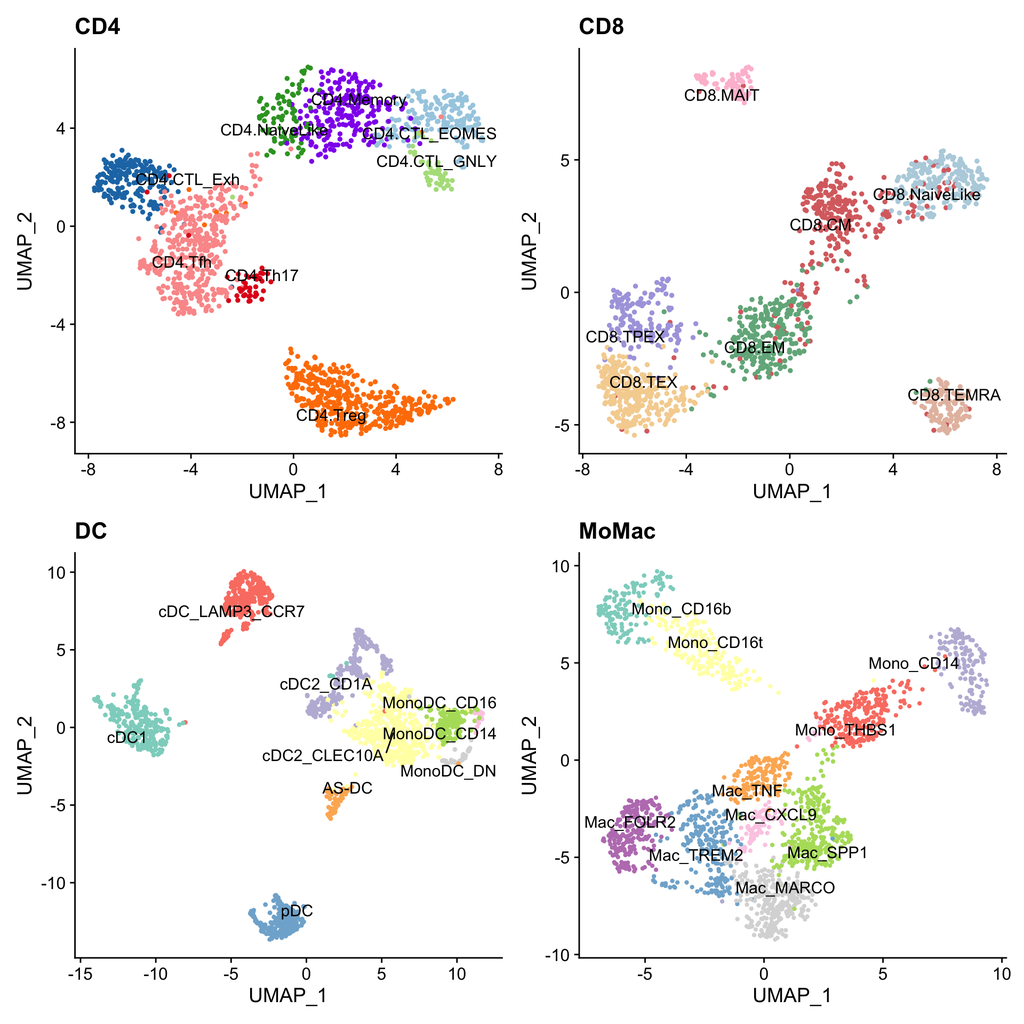

```r
library(ggplot2)
library(Seurat)

# Plot UMAP for each human reference map
refmap_umap <- lapply(names(ref.maps), function(x) {
    DimPlot(ref.maps[[x]], cols = ref.maps[[x]]@misc$atlas.palette, label = T, repel = T) +
        ggtitle(x) + NoLegend()
})

# Show all UMAPs
patchwork::wrap_plots(refmap_umap)
```

# Cell type classification

Classify cell types using HiTME, specifiy the species of origin of the dataset. Default is `human`.

```r
library(HiTME)

bassez <- Run.HiTME(bassez, ref.maps = ref.maps, species = "human")
```

After cell type classification, the object metadata has been updated with different layers of cell type classification of granularity. We can explore the new metadata content:

```r
# select the 3 layers or levels of granuality provided by HiTME
layers <- grep("layer[123]$", names(bassez@meta.data), value = T)

bassez@meta.data[1:20, layers]
```

| layer1 | layer2 | layer3 |
| --- | --- | --- |
| panDC | cDC2_CLEC10A | cDC2_CLEC10A_resting |
| CD4T | CD4.CTL_GNLY | CD4.CTL_GNLY_resting |
| panDC | cDC2_CLEC10A | cDC2_CLEC10A_resting |
| Fibroblast | Fibroblast | Fibroblast_resting |
| Fibroblast | Fibroblast | Fibroblast_resting |
| Endothelial | Endothelial | Endothelial_resting |
| Fibroblast | Fibroblast | Fibroblast_resting |
| CD4T | CD4.NaiveLike | CD4.NaiveLike_resting |
| NK | NK | NK_resting |
| CD4T | CD4.NaiveLike | CD4.NaiveLike_resting |

[output cut: 90 more lines]

We can also visualize the cell type annotation in a UMAP representation. Let’s do it for `layer1`, showing the broad cell type classification.

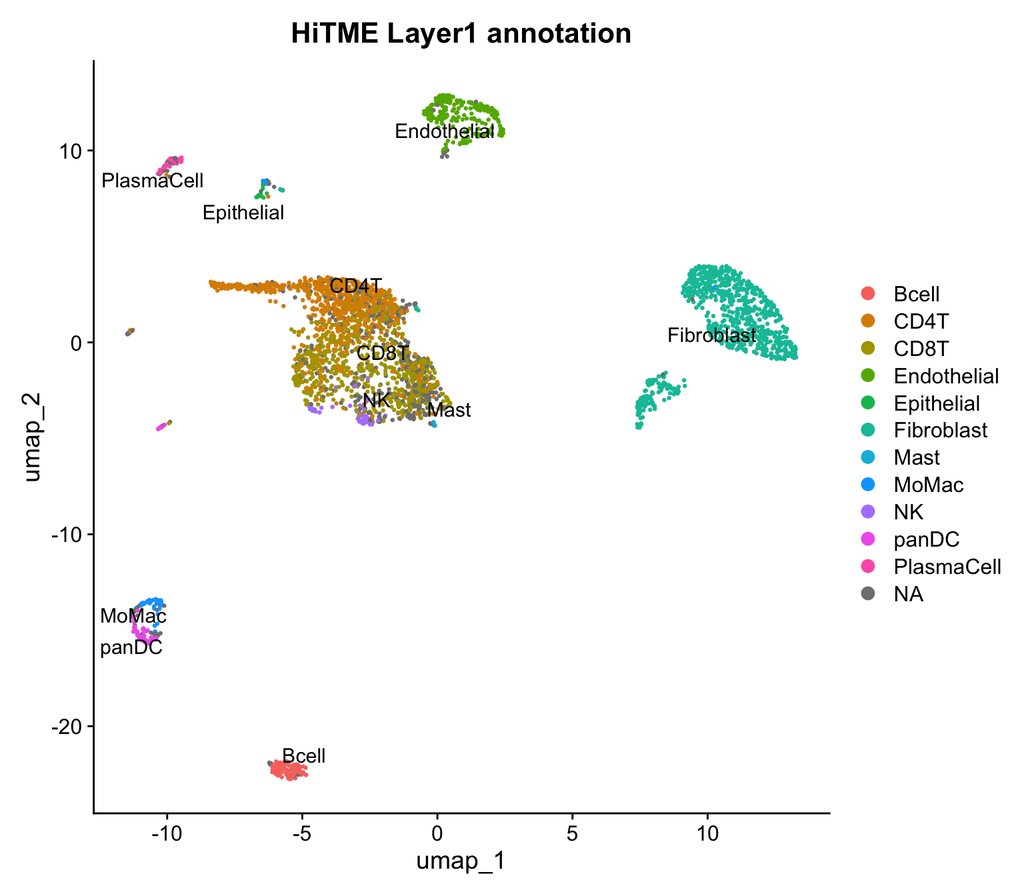

```r
# plot UMAP for layer1
DimPlot(bassez, group.by = "layer1", label = T, repel = T) + ggtitle("HiTME Layer1 annotation")
```

Finally, we can also explore the cell type classification at the different levels using barplots showing the number of each cell subtype.

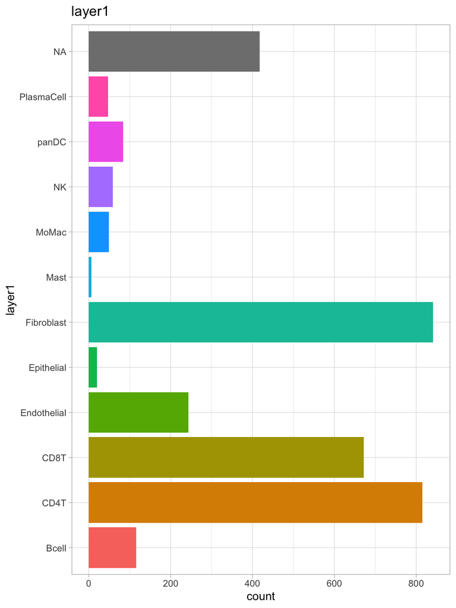

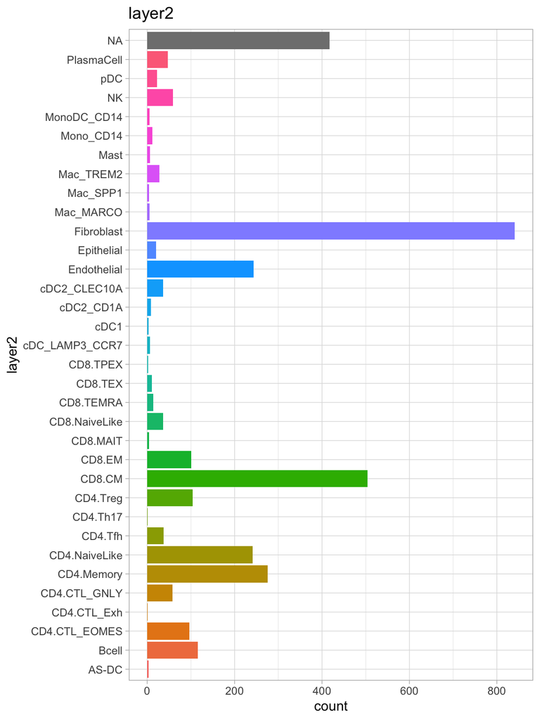

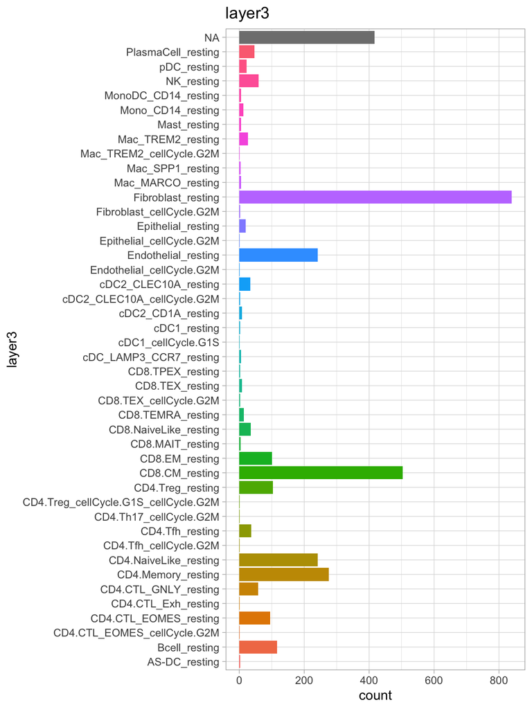

```r
# Show barplot for each level of granularity
barplots_layers <- lapply(layers, function(l) {
    ggplot(bassez@meta.data, aes(y = .data[[l]], fill = .data[[l]])) + geom_bar(show.legend = F) +
        ggtitle(l) + theme_light()
})

barplots_layers
```